# Using R for dNHC Research

## Setup

See 00_Setup.R

### Check installed packages

Create a list of required packages

```r
list.of.packages <- c("dplyr", # v.0.8.5
                      "tidyr", # v.1.0.2
                      "plyr", # v.1.8.6
                      "spocc", # v.1.0.8
                      "ridigbio", # v.0.3.5
                      "tibble", # v.3.0.0
                      "rbison",
                      "CoordinateCleaner",
                      "lubridate",
                      "ggplot2",
                      "gtools",
                      "leaflet",
                      "sp",
                      "rgeos",
                      "ggspatial",
                      "raster",
                      "agricolae",
                      "gridExtra")
```

### Compare to installed packages

Compare list of required to installed packages. Retain only missing packages (!).

```r
new.packages <- list.of.packages[!(list.of.packages %in% installed.packages()[,"Package"])]
```

### Install missing packages

Run for loop to install any missing packages. This loops through the list of new.packages and installs each.

```r
for(i in 1:length(new.packages)){
  install.packages(new.packages[i])
}
```

## Cleaning Data

See 01_CleaningData.R  
Download data and clean it.

### Load Packages

```r
library(CoordinateCleaner)
library(lubridate)
```

### Load Functions

This is a function I created with Natalie Patten (a very talent undergrad at UF). It will be part of her R package gatoRs (Geographic And Taxonomic Occurrence R-based Scrubbing).

```r
source("functions/DownloadingDataMore.R")
```

### Download Shortia galacifolia

Use spocc_combined to create a csv containing occurrence records from iDigBio, GBIF, and BISON. Find out more about this function [here](https://github.com/mgaynor1/long-winded-scripts/tree/master/OccurrenceData).

```r
spocc_combine("Shortia galacifolia", "data/Shortia_galacifolia_raw.csv")
```

### Read in downloaded data frame

```r
rawdf <- read.csv("data/Shortia_galacifolia_raw.csv")
```

### Cleaning

#### Inspect data frame

**What columns are included?**

```r
names(rawdf)
```

```
##  [1] "name"                          "basis"
##  [3] "date"                          "institutionID"
##  [5] "collectionCode"                "collectionID"
##  [7] "country"                       "county"
##  [9] "state"                         "locality"
## [11] "Latitude"                      "Longitude"
## [13] "ID"                            "coordinateUncertaintyInMeters"
## [15] "informationWithheld"           "habitat"
## [17] "prov"                          "spocc.latitude"
## [19] "spocc.longitude"               "spocc.prov"
## [21] "spocc.date"                    "spocc.name"
```

**How many observations do we start with?**

```r
nrow(rawdf)
```

```
## [1] 635
```

#### 1. Resolve taxon names

Inspect scientific names included in the raw df.

```r
unique(rawdf$name)
```

```
## [1] shortia galacifolia                Shortia galacifolia Torr. & A.Gray
## Levels: shortia galacifolia Shortia galacifolia Torr. & A.Gray
```

Create a list of accepted names based on the name column in your data frame

```r
search <-  c("Shortia galacifolia")
```

```r
df <- rawdf %>%
      filter(grepl(search, name, ignore.case =  TRUE)) %>%
      mutate(new.name = "Shortia galacifolia")
```

**How many observations do we have now?**

```r
nrow(df)
```

```
## [1] 635
```

#### 2. Decrease number of columns

##### Merge the two locality columns

```r
df$Latitude <-  dplyr::coalesce(df$Latitude, df$spocc.latitude)
df$Longitude <-  dplyr::coalesce(df$Longitude, df$spocc.longitude)
```

##### Merge the two date columns

```r
df$date <-  dplyr::coalesce(df$date, df$spocc.date)
```

##### Subset columns

Using the R package dplyr, we select and rename columns.

```r
df <- df %>%
      dplyr::select(ID = ID,
                name = new.name,
                basis = basis,
                coordinateUncertaintyInMeters = coordinateUncertaintyInMeters,
                informationWithheld = informationWithheld,
                lat = Latitude,
                long = Longitude,
                date = date)
```

#### 3. Clean localities

##### Remove NAs

Using the R package dplyr, we: 1. Filter out(!) any rows where long ‘is.na’. 2. Filter out(!) any rows where lat ‘is.na’.

```r
df <- df %>%
      filter(!is.na(long)) %>%
      filter(!is.na(lat))
```

**How many observations do we have now?**

```r
nrow(df)
```

```
## [1] 9
```

##### Fix precision

Using the R base function ‘round’, we round lat and long to two decimal places.

```r
df$lat <- round(df$lat, digits = 2)
df$long <- round(df$long, digits = 2)
```

##### Remove unlikely points

Remove points at 0.00, 0.00 Using the R package dplyr, we:  
1. Filter to retain rows where long is NOT(!) equal to 0.00. 2. Filter to retain rows where long is NOT(!) equal to 0.00.

```r
df <- df %>%
      filter(long != 0.00) %>%
      filter(lat != 0.00)
```

##### Remove bad coordinates

Remove coordinates in cultivated zones, botanical gardens, and outside our desired range Using the R package CoordinateCleaner, we first if points are at biodiversity institutions and remove any points that are occurring at institutions.

```r
df <- cc_inst(df,
              lon = "long",
              lat = "lat",
              species = "name")
```

```
## Testing biodiversity institutions
```

```
## Removed 0 records.
```

Next, we look for geographic outliers and remove outliers.

```r
df <- cc_outl(df,
              lon = "long",
              lat = "lat",
              species = "name")
```

```
## Testing geographic outliers
```

```
## Removed 1 records.
```

**How many observations do we have now?**

```r
nrow(df)
```

```
## [1] 8
```

#### 4. Remove Duplicates

##### Fix dates

Using the R package lubridate, we first parse the date into the same format.

```r
df$date <- lubridate::ymd(df$date)
```

Next you are going to seperate date into year, month, and day - where every column only contains one set of information.

```r
df <- df %>%
      dplyr::mutate(year = lubridate::year(date),
                month = lubridate::month(date),
                day = lubridate::day(date))
```

#### Remove rows with identical lat, long, year, month, and day

If a specimen shares lat, long, and event date we are assuming that it is identical. Many specimen lack date and lat/long, so this may be getting rid of information you would want to keep.

```r
df <- distinct(df, lat, long, year, month, day, .keep_all = TRUE)
```

**How many observations do we have now?**

```r
nrow(df)
```

```
## [1] 8
```

#### 5. Save Cleaned .csv

```r
write.csv(df, "data/Shortia_galacifolia_061521-cleaned.csv", row.names = FALSE)
```

## Mapping

See 02_Mapping.R.  
Map occurrence records using ggplot2 and leaflet.

### Load Packages

```r
library(ggplot2)
library(leaflet)
library(sp)
library(rgeos)
library(ggspatial)
```

### Read data file

```r
df <- read.csv("data/Shortia_galacifolia_061521-cleaned.csv")
```

### Map using ggplot2

Make a simple map using ggplot2.

#### Set base maps

Here we download a USA map, a state level USA map, and a county level USA map.

```r
USA <- borders(database = "usa", colour = "gray50", fill = "gray50")
states <-  borders("state", colour = "black", fill = NA)
county <- borders(database = "county", colour = "gray40", fill = NA)
```

#### Plot

Here we are going to add our USA map and the occurrence points. Next, we zoom into our area of interest. Then, we fix the x and y labels. Finally, we add a scale and a north arrow

```r
simple_map <- ggplot() +
              USA +
              # Better to add state or county here - order matters!
              geom_point(df,
                         mapping = aes(x = long, y = lat),
                         col = "blue") +
              coord_sf(xlim = c(-86, -76), ylim = c(30, 38)) +
              xlab("Longitude") +
              ylab("Latitude") +
              annotation_scale() +
              annotation_north_arrow( height = unit(1, "cm"),
                                      width = unit(1, "cm"),
                                      location = "tl")
```

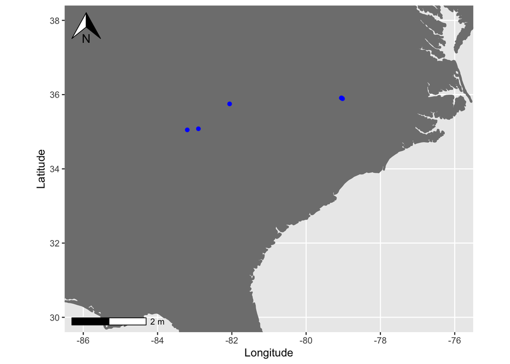

```r
simple_map
```

##### Add States

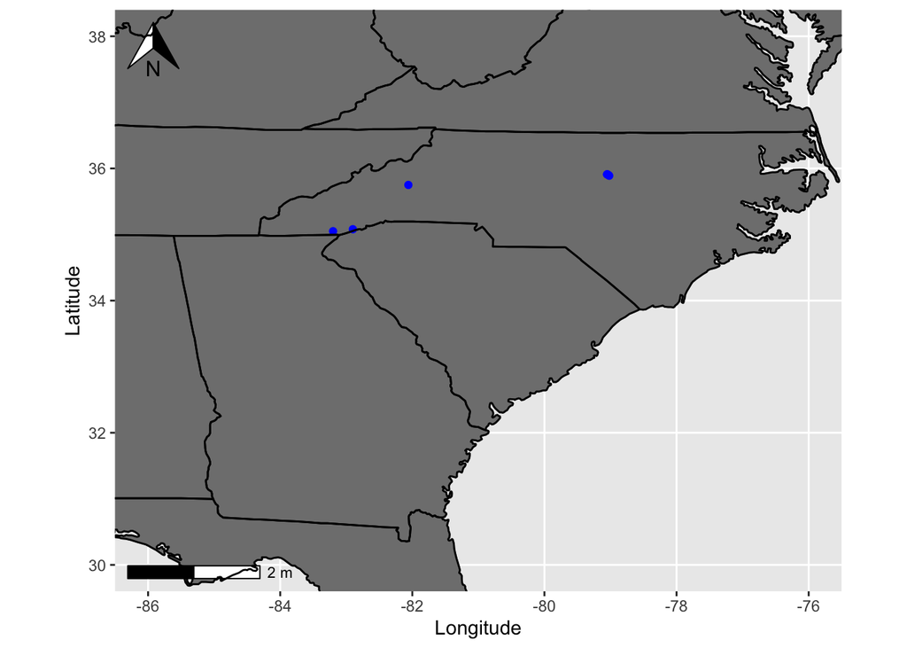

```r
simple_map + states
```

##### Add Counties

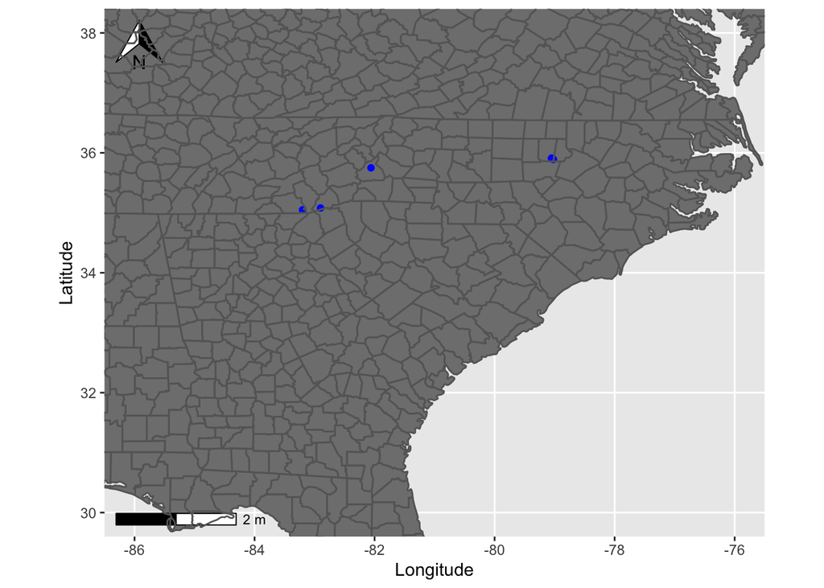

```r
simple_map + county
```

### Map using Leaflet

Find out more about [leaflet here](https://rstudio.github.io/leaflet/). Basically it uses JavaScript to make interactive maps.

#### Make points spatial

```r
pts <- SpatialPoints(df[,7:6])
```

#### Make a simple leaflet map

```r
m <- leaflet(pts) %>%
     addCircles() %>%
     addTiles()
m
```

[interactive chart not shown]

#### Set extent and zoom out

```r
m <- fitBounds(m, -86, 30, -76, 38)
m
```

[interactive chart not shown]

#### Make fancy icon

```r
ShortiaIcon <- makeIcon(
  iconUrl = "https://live.staticflickr.com/2914/32392790054_27192e77e6_b.jpg",
  iconWidth = 18, iconHeight = 28,
  iconAnchorX = 17, iconAnchorY = 27
)

m <- leaflet(pts) %>%
     addTiles()  %>%
     addMarkers(icon = ShortiaIcon)
m
```

[interactive chart not shown]

#### Add label to see long, lat

```r
m <- leaflet(pts) %>%
     addTiles()  %>%
     addMarkers(label = paste0(df$long, ", ", df$lat))
m
```

[interactive chart not shown]

#### Add rectangle marking extent

```r
m <- leaflet(pts) %>%
     addTiles()  %>%
     addMarkers(label = paste0(df$long, ", ", df$lat))   %>%
     addRectangles(
        lng1 = max(df$long), lat1 = max(df$lat),
        lng2 = min(df$long), lat2 = min(df$lat),
        fillColor = "transparent")
m
```

[interactive chart not shown]

## Point Statistics

See 03_PointStats.R.  
Point sample and run a simple ANOVA.

### Load Packages

```r
library(gtools)
library(raster)
library(dplyr)
library(tibble)
library(agricolae)
library(gridExtra)
```

### Read data files

```r
dfS <- read.csv("data/Shortia_galacifolia_061521-cleaned.csv")
dfG <- read.csv("data/Galax_urceolata_061521-cleaned.csv")
```

### Modify the data frame

#### Combined the two df

```r
df <- rbind(dfS, dfG)
```

#### Subset spatial points

```r
pts <- SpatialPoints(df[,7:6])
```

### Import BioClim files

#### List BioClim files

```r
list <- list.files("data/bio/",
                    full.names = TRUE,
                    recursive = FALSE)
```

#### Order list using gtools

```r
list <- mixedsort(sort(list))
```

#### Load the rasters

```r
envtStack <- raster::stack(list)
```

### Point Sample

##### Extract value for each point

```r
ptExtracted <- raster::extract(envtStack, pts)
```

#### Convert to data frame

```r
ptExtracteddf <- as.data.frame(ptExtracted)
```

#### Add species name

```r
ptExtracteddf <- ptExtracteddf %>%
                 mutate(name = as.character(df$name))
```

### ANOVA

ANOVA or an analysis of variance. To run an ANOVA, you first set the linear model using lm. Next, the aov function will run the ANOVA.

```r
bio1aov <- aov(lm(ptExtracteddf[, 1] ~ name, data = ptExtracteddf))
bio1aov
```

```
## Call:
##    aov(formula = lm(ptExtracteddf[, 1] ~ name, data = ptExtracteddf))
##
## Terms:
##                      name Residuals
## Sum of Squares   14.98401 153.62829
## Deg. of Freedom         1        31
##
## Residual standard error: 2.226152
## Estimated effects may be unbalanced
## 2 observations deleted due to missingness
```

#### Tukey HSD test

Here we will do a multiple comparisons of treatments by means of Tukey.

```r
b1 <- HSD.test(bio1aov, trt = "name", alpha = 0.05)
b1
```

```
## $statistics
##    MSerror Df     Mean       CV
##   4.955751 31 13.07235 17.02947
##
## $parameters
##    test name.t ntr StudentizedRange alpha
##   Tukey   name   2         2.884308  0.05
##
## $means
##                     ptExtracteddf[, 1]      std  r       Min      Max      Q25
## Galax urceolata               12.69117 2.386864 25  8.533334 17.05833 11.06667
## Shortia galacifolia           14.26354 1.553680  8 10.841666 15.25833 13.70729
##                          Q50      Q75
## Galax urceolata     13.52917 14.14583
## Shortia galacifolia 15.15833 15.18229
##
## $comparison
## NULL
##
## $groups
##                     ptExtracteddf[, 1] groups
## Shortia galacifolia           14.26354      a
## Galax urceolata               12.69117      a
##
## attr(,"class")
## [1] "group"
```

#### Separate the groups

```r
bio1_group <- b1$groups
bio1_group <- rownames_to_column(bio1_group, var = "name")
bio1_group <- bio1_group %>%
              dplyr::select(name, groups)
bio1_group
```

```
##                  name groups
## 1 Shortia galacifolia      a
## 2     Galax urceolata      a
```

#### Subset from the original df

Here we subset the name and bio_1 column from the original df.

```r
part <- ptExtracteddf %>%
        dplyr::select(name, bio_1)
```

#### Join the subset df to the bio1_group data frame

```r
bio1pl <- left_join(part, bio1_group, by = "name")
```

#### Plot

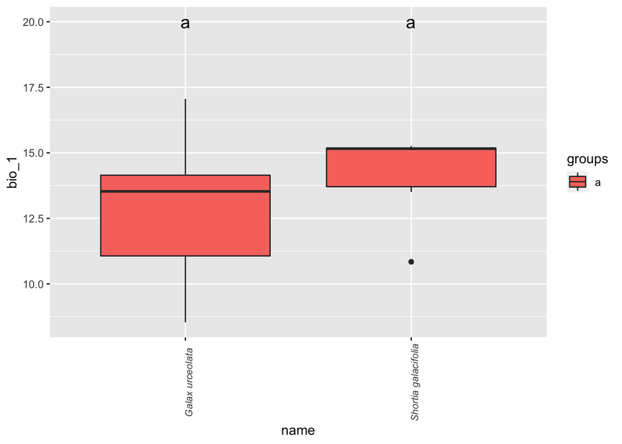

```r
bio1_aov_plot <- ggplot(bio1pl, aes(x = name, y = bio_1)) +
                  geom_boxplot(aes(fill = groups)) +
                  geom_text(data = bio1_group,
                            mapping = aes(x = name,
                                          y = 20,
                                          label = groups),
                            size = 5, inherit.aes = FALSE) +
                  theme(axis.text.x = element_text(angle = 90,
                                                   size = 8,
                                                   face = 'italic'))
bio1_aov_plot
```

#### Loop through all variables

First, set a list of the variable names and an empty list to store the resulting plots in.

```r
variablelist <- colnames(ptExtracteddf)[1:20]
plotlist <- c()
```

```r
for(i in 1:20){
      ### ANOVA
      bioaov <- aov(lm(ptExtracteddf[, i] ~ name, data = ptExtracteddf))
      ### Tukey HSD test
      b <- HSD.test(bioaov, trt = "name", alpha = 0.05)
      ### Separate the groups
      bio_group <- b$groups
      bio_group <- rownames_to_column(bio_group, var = "name")
      bio_group <- bio_group %>%
                   dplyr::select(name, groups)
      ### Subset from the original df
      part <- ptExtracteddf %>%
              dplyr::select(name, variablelist[i])
      #### Join the subset df to the bio_group data frame
      biopl <- left_join(part, bio_group, by = "name")
      #### Plot
      plotlist[[i]] <- ggplot(biopl, aes(x = name, y = biopl[,2])) +
                       geom_boxplot(aes(fill = groups)) +
                       geom_text(data = bio_group,
                                mapping = aes(x = name,
                                              y = (max(na.omit(biopl[,2]))* 1.3),
                                              label = groups),
                                size = 5, inherit.aes = FALSE) +
                               scale_x_discrete(labels = c('G', 'S')) +
                       ggtitle(label  = paste(variablelist[i]))

}
```

[figure not shown]

```r
gridExtra::grid.arrange(grobs = plotlist)
```